# Projects in Data Science Activity A3a: Multivariate Visualizations

Additional reading: Chapter 7 of *Visualize This*, by Nathan Yau.

# Exploring SAT Scores

Though far from a perfect assessment of academic preparedness, SAT scores are often used as one measurement of a state’s education system. The `education` data stored at https://www.macalester.edu/~ajohns24/data/sat.csv contain various education variables for each state:

```r
education <- read_csv("https://www.macalester.edu/~ajohns24/data/sat.csv")
```

Table 1: The first few rows of the SAT data.

| State | expend | ratio | salary | frac | verbal | math | sat | fracCat |
| --- | --- | --- | --- | --- | --- | --- | --- | --- |
| Alabama | 4.405 | 17.2 | 31.144 | 8 | 491 | 538 | 1029 | (0,15] |
| Alaska | 8.963 | 17.6 | 47.951 | 47 | 445 | 489 | 934 | (45,100] |
| Arizona | 4.778 | 19.3 | 32.175 | 27 | 448 | 496 | 944 | (15,45] |
| Arkansas | 4.459 | 17.1 | 28.934 | 6 | 482 | 523 | 1005 | (0,15] |
| California | 4.992 | 24.0 | 41.078 | 45 | 417 | 485 | 902 | (15,45] |
| Colorado | 5.443 | 18.4 | 34.571 | 29 | 462 | 518 | 980 | (15,45] |

A codebook is provided by Danny Kaplan who also made these data accessible:

Figure 1: Codebook for SAT data. Source: https://www.macalester.edu/~kaplan/ISM/datasets/data-documentation.pdf

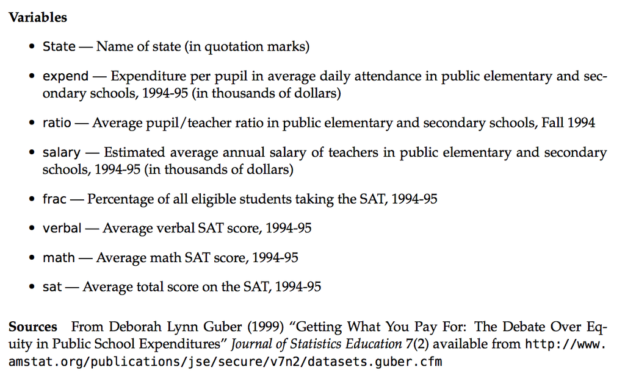

To examine the variability in average SAT scores from state to state, let’s start with a univariate density plot:

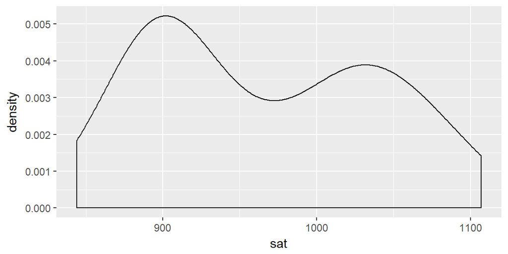

```r
ggplot(education, aes(x=sat)) + geom_density()
```

The first question we’d like to answer is to what degree do per pupil spending (`expend`) and teacher `salary` *explain* this variability? We can start by plotting each against `sat`, along with a best fit linear regression model:

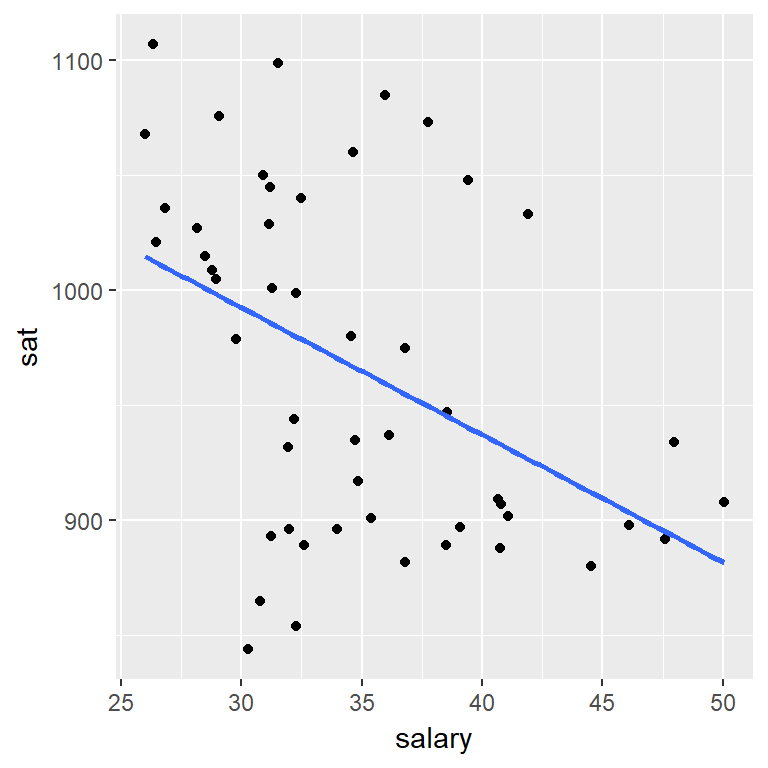

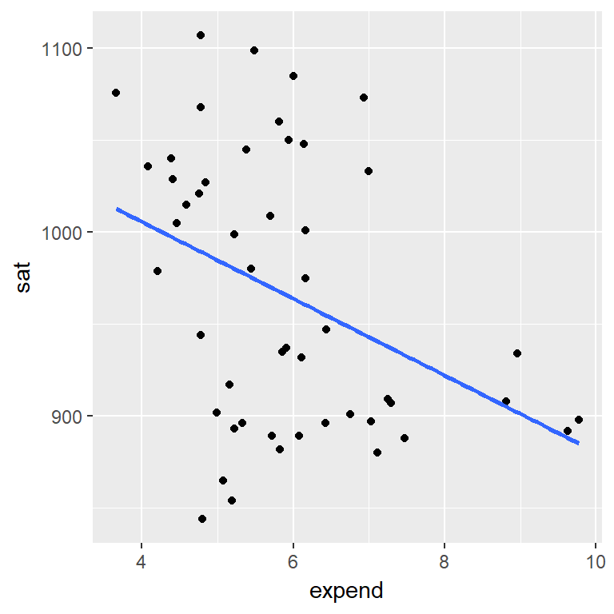

```r
ggplot(education, aes(y=sat,x=salary))+
  geom_point()+
  geom_smooth(se=FALSE,method="lm")
ggplot(education, aes(y=sat,x=expend))+
  geom_point()+
  geom_smooth(se=FALSE,method="lm")
```

Is there anything that surprises you here?!

**Exercise 1** Make a scatterplot visualization that demonstrates the relationship between `sat`, `salary`, and `expend`. Summarize the trivariate relationship between `sat`, `salary`, and `expend`. Hint: Include some model smooths with `geom_smooth()` to help highlight the trends.

1. Make a visualization that demonstrates the relationship between `fracCat` and `sat`. What story does your graphic tell?
2. Make a visualization that demonstrates the relationship between `fracCat`, `sat`, and `expend`. What story does your graphic tell?
3. This is a demonstration of which statistical phenomenon?

# Other Multivariate Visualization Techniques

## Heat maps

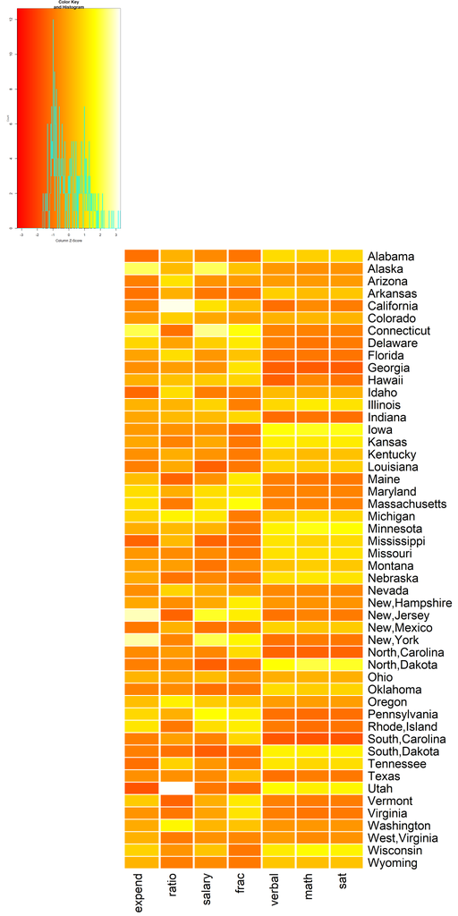

```r
ed<-as.data.frame(education) # convert from tibble to data frame
row.names(ed)<-ed$State
ed<-ed[,2:8]
ed_mat <- data.matrix(ed)
heatmap.2(ed_mat, Rowv=NA, Colv=NA, scale="column",
          col=heat.colors(256),margins=c(10,20),
          colsep=c(1:7),rowsep=(1:50), sepwidth=c(0.05,0.05),
          sepcolor="white",cexRow=3,cexCol=3,trace="none",
          dendrogram="none")
```

**Heat map with row clusters**

It can be tough to identify interesting patterns by visually comparing across rows and columns. Including *dendrograms* helps to identify interesting clusters.

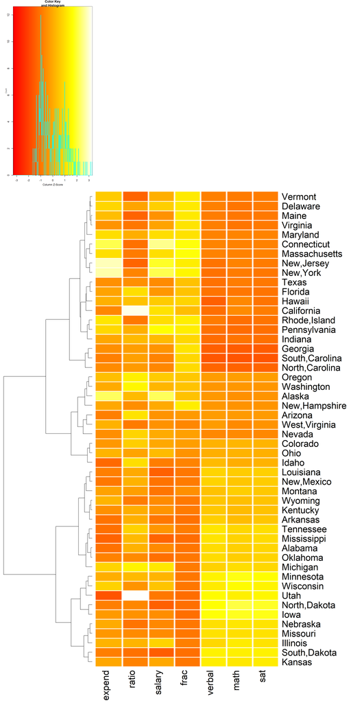

```r
heatmap.2(ed_mat, Colv=NA, scale="column",
          col=heat.colors(256),margins=c(10,20),
          colsep=c(1:7),rowsep=(1:50), sepwidth=c(0.05,0.05),
          sepcolor="white",cexRow=3,cexCol=3,trace="none",
          dendrogram="row")
```

**Heat map with column clusters**

We can also construct a heat map which identifies interesting clusters of columns (variables).

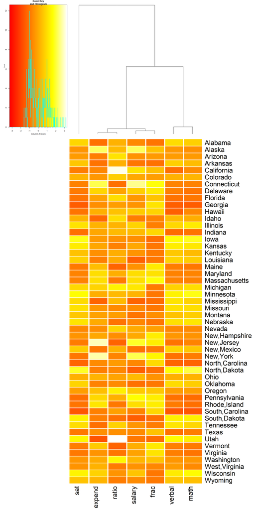

```r
heatmap.2(ed_mat, Rowv=NA, scale="column",
          col=heat.colors(256),margins=c(10,20),
          colsep=c(1:7),rowsep=(1:50), sepwidth=c(0.05,0.05),
          sepcolor="white",cexRow=3,cexCol=3,trace="none",
          dendrogram="column")
```

## Star plots

There’s more than one way to visualize multivariate patterns. Like heat maps, these star plot visualizations indicate the relative scale of each variable for each state. With this in mind, you can use the star maps to identify which state is the most “unusual.” You can also do a quick scan of the second image to try to cluster states. How does that clustering compare to the one generated in the heat map with row clusters above?

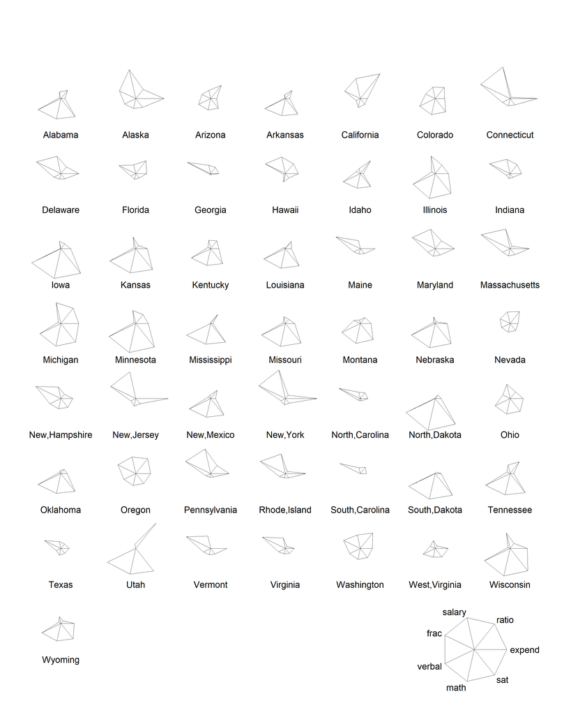

```r
stars(ed_mat, flip.labels=FALSE,
      key.loc=c(15,1.5),cex=1.5)
```

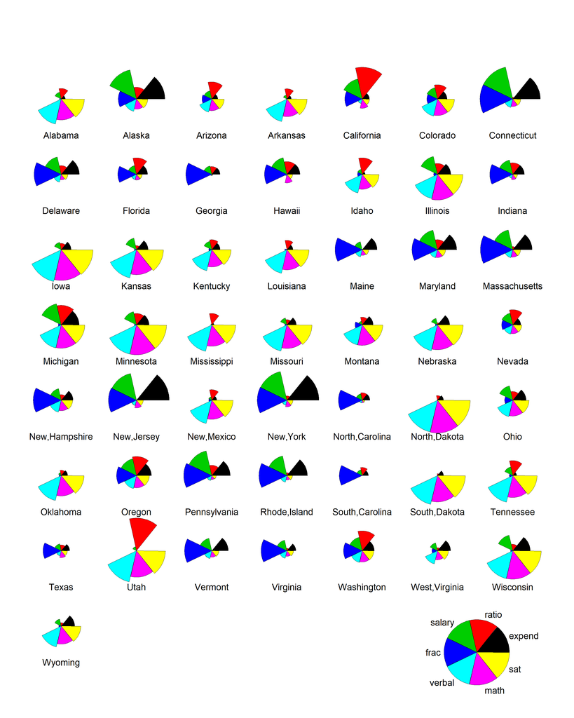

```r
stars(ed_mat, flip.labels=FALSE,
      key.loc=c(15,1.5), cex=1.5,draw.segments=TRUE)
```